# Tidyverse avanzado y principios de visualización

Author

Diplomatura PEEC - UBA

```r
# Cargamos paquetes clave:1
library(tidyverse)      # Data manipulation and visualization
library(lubridate)      # Date handling
library(scales)         # Better axis formatting
library(gt)             # Beautiful tables
library(plotly)         # Interactive plots
library(patchwork)      # Combine multiple plots
library(tsibble)        # Time series tibbles
library(fabletools)     # Time series toolkit
library(feasts)         # Feature extraction for time series
library(glue)           # String interpolation

# Set theme for consistent visualization
theme_set(theme_minimal(base_size = 12) +
          theme(plot.title = element_text(face = "bold"),
                plot.subtitle = element_text(face = "italic", size = 10),
                plot.caption = element_text(size = 8, hjust = 0)))
```

## Complejizar tidyverse

Hasta el momento se ha avanzado sobre funciones que componen el paquete `tidyverse` en forma individual, pero no hemos observado esquemas que concatenen estas funciones en un **flujo de trabajo más complejos**. Este tipo de esquemas, o procesos, tienden a ser el trabajo más típico de un usuario/a en R, ya que para sintetizar grandes volumenes de información en indicadores o métricas, se requieren procesos previos sobre los datos.

### El operador pipe (%>%) como conector fundamental

Este instrumento o herramienta es fundamental para los flujos de trabajo, ya que es el operador a través del cual se concatenan las operaciones u ordenes que están codificadas. Su esencia se encuentra en la posibilidad de realizar múltiples operaciones, de forma secuencial y velozmente, al mismo tiempo que dicho conjunto de operaciones quedan escritas en una secuencia de código. Se trata únicamente de una transformación sintáctica: nos permite ordenar el código

Pipe del Tidyverse

Sin Pipe

```r
library(dplyr)
df %>%
  group_by(category) %>%
  summarize(media = mean(valor))
```

```r
summarize(group_by(df, category), media = mean(valor))
```

## Flujo de trabajo y base de datos

En esta clase abarcaremos el análisis y la práctica de flujos más complejos con `tidyverse`, a partir del uso de una base de datos de SIPA. Para ello, se procederá a importar dicha base y contar con ella en el ambiente de R.

```r
SIPA <- read.csv("../../bases/base_sipa.csv")
```

### Explorar la base

En primer lugar, se puede observar con que variables cuenta la base.

```r
names(SIPA)
```

```
[1] "Período"   "Variable"  "Geografia" "Valor"
```

Así, dado que una columna se llama “Variable”, puede observarse al interior de esta qué etiquetas aparecen y cuál la frecuencia de cada una de estas.

```r
table(SIPA$Variable)
```

```
Asalariados registrados en el sector privado
                                        2184
      Empleo asalariado en el sector privado
                                         310
      Empleo asalariado en el sector público
                                         310
                Empleo en casas particulares
                                         310
 Remuneración mediana - \ncon estacionalidad
                                         191
 Remuneración mediana - \nsin estacionalidad
                                         191
Remuneración promedio - \nsin estacionalidad
                                         191
Remuneración promedio -\n con estacionalidad
                                         191
                                       Total
                                         310
            Trabajo Independientes Autónomos
                                         310
          Trabajo Independientes Monotributo
                                         310
  Trabajo Independientes Monotributo\nSocial
                                         310
```

De este modo, es posible incluir una variable de defina el año de cada observación, a fin de obtener datos que den cuenta de una frecuencia anual y no solo mensual.

```r
SIPA <- SIPA %>%
  mutate(Año = year(Período))
```

La función `year()` forma parte del paquete `lubridate`, el cual es de gran utilidad para trabajar con el formato fecha de variables al interior de una base de datos. El input para `year()` es una variable de clase fecha de nuestro data set, y su output es el año al cual corresponde el input. Al mismo tiempo, como puede verse, dicha fecha se utiliza al interior de la función `mutate()`, la cual como ya se ha visto opera creando variables nuevas o reescribiendo las ya existentes en caso de indicar el mismo nombre.

Por tanto, el comando puede leerse cómo: creese una variable llamada `Año` que tenga por contenido el año de cada uno de las fechas al interior de la variable `Período`. Así, R irá fila por fila tomando como input el contenido de la variable `Perìodo` y devolviendo como output el año al cual corresponde cada uno de los valores al interior de `Período`.

Una vez que se cuenta con la variable `Año`, se procederá a estudiar diferentes cálculos posibles.

### Primera concatenación: desde el group_by()

Un primer procesamiento de utilidad refiere a la utilización de la función `group_by()`, la cual permite “iterar” algún proceso lógico para todos los valores que toma alguna variable de nuestro dataset. Por ejemplo:

```r
# flujo1 <- SIPA %>%
#   group_by(Año, Variable) %>%
#   summarise(Promedio = mean(Valor))
#
# flujo1
```

En este caso, el objetivo está en agrupar un procesamiento determinado para cada valor que tomen las columnas `Año` y `Variable`. El procesamiento en cuestión es calcular el promedio del contenido de la columna `Valor`.

Por ende, el código puede leerse como: creese la columna `Promedio`, la cual debe contener el promedio del contenido de la columna `Valor` para cada combinación de `Año` y `Variable`.

Este tipo de cálculos generales, también pueden especificarse para algún valor, o rango de valores, de las variables para las cuales se hace el agrupamiento (en este caso `Año` y `Variable`). Por ejemplo, acotemos el cálculo solo para una de las categorías dentro de `Variables`.

```r
# flujo2 <- SIPA %>%
#   filter(Variable == "Empleo asalariado en el sector privado") %>%
#   group_by(Año) %>%
#   summarise(Promedio = mean(Valor))
#
# flujo2
```

En este caso, se incluye un filtro para `Variable`, el cual busca acotar el cálculo para todos los casos contenidos en la categoría *“Empleo asalariado en el sector privado”*.

Por lo tanto, el código puede leerse como: calculese el promedio de la columna `Valor`, para todo el conjunto de datos que compartan el mismo valor de la columna `Año`, pero solo para la categorìa *“Empleo asalariado en el sector privado”* de la columna `Variable`.

A su vez, es importante señalar que en este tipo de procesamientos, R ordena las filas desde el valor más bajo al más alto de la primera columna, por defecto. Sin embargo, el orden puede modificarse al especificar un orden particular con la función `arrange()`. Por ejemplo:

```r
# flujo3 <- SIPA %>%
#   filter(Variable == "Empleo en casas particulares") %>%
#   group_by(Año) %>%
#   summarise(Promedio = mean(Valor)) %>%
#   arrange(-Año)
```

En este caso, se repite el procesamiento previo, pero luego de estimar el promedio se ordena a las filas desde el mayor valor de la variable `Año` al menor. Notar que esto es así porque se especificó un `-` delante del nombre de la variable al interior de la función `arrange()`, en caso de no incluir este signo el orden irá del menor valor al mayor.

Ideas para la primera parte:

1. Tomar series en niveles, pasarlas a logs y después visualizar

Ideas para la visualización:

1. Mirar boxplots

Al final mostrar por encima el HTML que hizo Vladi para EPH

# Import SIPA dataset with readr (tidyverse) for better import control

```r
SIPA <- read_csv("../../bases/base_sipa.csv",
                 show_col_types = FALSE) %>%
  # Convert Período to proper date format immediately
  mutate(Período = ymd(Período),
         Año = year(Período),
         Mes = month(Período, label = TRUE, abbr = TRUE),
         Trimestre = quarter(Período))
```

# Display dataset structure using gt for a nicer table

```r
SIPA %>%
  slice_head(n = 6) %>%
  gt() %>%
  tab_header(
    title = "SIPA Dataset Preview",
    subtitle = "First 6 rows of the employment data"
  ) %>%
  tab_style(
    style = cell_fill(color = "aliceblue"),
    locations = cells_column_labels()
  ) %>%
  fmt_number(
    columns = vars(Valor),
    decimals = 1
  ) %>%
  opt_interactive(
    use_compact_mode = TRUE,
    use_highlight = TRUE
  )
```

SIPA Dataset Preview

First 6 rows of the employment data

| Período | Variable | Geografia | Valor | Año | Mes | Trimestre |
| --- | --- | --- | --- | --- | --- | --- |
| 2009-01-01 | Asalariados registrados en el sector privado | BUENOS AIRES | 1787.64 | 2009 | ene | 1 |
| 2009-01-01 | Asalariados registrados en el sector privado | Cdad. Autónoma de Buenos Aires | 1469.941 | 2009 | ene | 1 |
| 2009-01-01 | Asalariados registrados en el sector privado | CATAMARCA | 29.789 | 2009 | ene | 1 |
| 2009-01-01 | Asalariados registrados en el sector privado | CHACO | 59.917 | 2009 | ene | 1 |
| 2009-01-01 | Asalariados registrados en el sector privado | CHUBUT | 93.274 | 2009 | ene | 1 |
| 2009-01-01 | Asalariados registrados en el sector privado | CÓRDOBA | 457.589 | 2009 | ene | 1 |

# More informative variable exploration

```r
SIPA %>%
  count(Variable) %>%
  mutate(Proportion = n / sum(n)) %>%
  arrange(desc(n)) %>%
  gt() %>%
  tab_header(
    title = "Distribution of Variable Categories",
    subtitle = "Frequency and proportion of each category"
  ) %>%
  fmt_percent(
    columns = vars(Proportion),
    decimals = 1
  ) %>%
  tab_style(
    style = cell_fill(color = "lightcyan"),
    locations = cells_body(
      columns = vars(Variable),
      rows = 1
    )
  )
```

Distribution of Variable Categories

Frequency and proportion of each category

| Variable | n | Proportion |
| --- | --- | --- |
| Asalariados registrados en el sector privado | 2184 | 42.7% |
| Empleo asalariado en el sector privado | 310 | 6.1% |
| Empleo asalariado en el sector público | 310 | 6.1% |
| Empleo en casas particulares | 310 | 6.1% |
| Total | 310 | 6.1% |
| Trabajo Independientes Autónomos | 310 | 6.1% |
| Trabajo Independientes Monotributo | 310 | 6.1% |
| Trabajo Independientes Monotributo Social | 310 | 6.1% |
| Remuneración mediana - con estacionalidad | 191 | 3.7% |
| Remuneración mediana - sin estacionalidad | 191 | 3.7% |
| Remuneración promedio - con estacionalidad | 191 | 3.7% |
| Remuneración promedio - sin estacionalidad | 191 | 3.7% |

## Advanced Tidyverse Workflows

### The pipe operator: From %>% to |>

R 4.1 introduced a native pipe operator `|>` as an alternative to the magrittr pipe `%>%`. Both accomplish similar goals, but the native pipe is slightly faster and has fewer dependencies.

```r
# Traditional magrittr pipe
SIPA %>%
  group_by(Año) %>%
  summarise(mean_value = mean(Valor))
```

```
# A tibble: 16 × 2
     Año mean_value
   <dbl>      <dbl>
 1  2009       586.
 2  2010       694.
 3  2011       867.
 4  2012      1257.
 5  2013      1433.
 6  2014      1682.
 7  2015      1989.
 8  2016      3074.
 9  2017      6458.
10  2018      7826.
11  2019     10601.
12  2020     14149.
13  2021     20368.
14  2022     34248.
15  2023     77166.
16  2024    225131.
```

```r
# New native pipe (R 4.1+)
SIPA |>
  group_by(Año) |>
  summarise(mean_value = mean(Valor))
```

```
# A tibble: 16 × 2
     Año mean_value
   <dbl>      <dbl>
 1  2009       586.
 2  2010       694.
 3  2011       867.
 4  2012      1257.
 5  2013      1433.
 6  2014      1682.
 7  2015      1989.
 8  2016      3074.
 9  2017      6458.
10  2018      7826.
11  2019     10601.
12  2020     14149.
13  2021     20368.
14  2022     34248.
15  2023     77166.
16  2024    225131.
```

### Grouped operations with cleaner code

Let’s calculate annual averages for each variable category, using modern tidyverse functions:

```r
annual_averages <- SIPA |>
  group_by(Año, Variable) |>
  summarise(
    Promedio = mean(Valor),
    Mediana = median(Valor),
    Min = min(Valor),
    Max = max(Valor),
    CV = sd(Valor) / mean(Valor), # Coefficient of variation
    .groups = "drop"  # New argument to avoid group structure warnings
  ) |>
  arrange(Variable, Año)

# Display results with gt for better presentation
annual_averages |>
  filter(Año >= 2018) |>  # Focus on recent years for clarity
  gt(groupname_col = "Variable") |>  # Group by Variable
  tab_header(
    title = "Annual Economic Indicators",
    subtitle = "Summary statistics by year and indicator type"
  ) |>
  fmt_number(
    columns = vars(Promedio, Mediana, Min, Max),
    decimals = 1
  ) |>
  fmt_percent(
    columns = vars(CV),
    decimals = 1
  ) |>
  tab_style(
    style = cell_fill(color = "lightyellow"),
    locations = cells_body(
      columns = vars(Promedio),
      rows = CV > 0.1  # Highlight high-variation indicators
    )
  ) |>
  opt_interactive(
    use_search = TRUE,
    use_filters = TRUE
  )
```

Annual Economic Indicators

Summary statistics by year and indicator type

| Año | Promedio | Mediana | Min | Max | CV | [] |
| --- | --- | --- | --- | --- | --- | --- |
| 2018 | 3169.46638885609 | 3135.46396550547 | 101.006018225165 | 6322.588 | 0.988661576033663 | Empleo asalariado en el sector privado |
| 2019 | 3096.7284042638 | 3061.02033089339 | 98.6038215492324 | 6187.63 | 0.988679542127 | Empleo asalariado en el sector privado |
| 2020 | 2973.02925383548 | 2933.63837391894 | 94.4741467875694 | 6028.392 | 0.988871796176826 | Empleo asalariado en el sector privado |
| 2021 | 3002.89588663422 | 2974.65560086435 | 95.817851857032 | 6027.687 | 0.988662717380885 | Empleo asalariado en el sector privado |
| 2022 | 3135.28116823052 | 3086.21641405535 | 99.3999953815563 | 6296.204 | 0.988719492354163 | Empleo asalariado en el sector privado |
| 2023 | 3234.32037584151 | 3219.0092074089 | 103.725069616487 | 6387.707 | 0.988595733838073 | Empleo asalariado en el sector privado |
| 2024 | 3180.40736881836 | 3151.1076272961 | 101.507348648114 | 6363.884 | 0.990620403975995 | Empleo asalariado en el sector privado |
| 2018 | 1643.06605473265 | 1626.89070794255 | 122.976062195598 | 3195.377 | 0.944263478584877 | Empleo asalariado en el sector público |
| 2019 | 1656.91069389736 | 1631.97229779728 | 123.292646155213 | 3249.054 | 0.944335525486661 | Empleo asalariado en el sector público |
| 2020 | 1666.90991993429 | 1657.04336753872 | 125.25068629883 | 3257.579 | 0.94427171965429 | Empleo asalariado en el sector público |

[output cut: 67 more lines]

### Using across() for more powerful operations

The `across()` function, introduced in dplyr 1.0.0, lets us apply the same function(s) to multiple columns:

```r
# Calculate summary statistics for all numeric columns by year
SIPA |>
  select(Año, Variable, Valor) |>
  filter(Variable == "Empleo asalariado en el sector privado") |>
  group_by(Año) |>
  summarise(
    across(
      Valor,
      list(
        Media = mean,
        Mediana = median,
        Desv = sd,
        Cambio = ~(last(.) / first(.)) - 1
      ),
      .names = "{.fn}"
    )
  ) |>
  gt() |>
  fmt_percent(
    columns = vars(Cambio),
    decimals = 1
  ) |>
  tab_spanner(
    label = "Annual Statistics",
    columns = vars(Media, Mediana, Desv, Cambio)
  )
```

| Año | Annual Statistics Media | Annual Statistics Mediana | Annual Statistics Desv | Annual Statistics Cambio |
| --- | --- | --- | --- | --- |
| 2012 | 3082.810 | 3061.455 | 3047.729 | −98.4% |
| 2013 | 3105.928 | 3083.046 | 3070.546 | −98.4% |
| 2014 | 3107.353 | 3088.123 | 3071.983 | −98.4% |
| 2015 | 3165.638 | 3149.907 | 3129.548 | −98.3% |
| 2016 | 3143.082 | 3118.832 | 3107.346 | −98.4% |
| 2017 | 3165.238 | 3145.983 | 3129.212 | −98.3% |
| 2018 | 3169.466 | 3135.464 | 3133.530 | −98.4% |
| 2019 | 3096.728 | 3061.020 | 3061.672 | −98.4% |
| 2020 | 2973.029 | 2933.638 | 2939.945 | −98.4% |
| 2021 | 3002.896 | 2974.656 | 2968.851 | −98.3% |
| 2022 | 3135.281 | 3086.216 | 3099.914 | −98.3% |
| 2023 | 3234.320 | 3219.009 | 3197.435 | −98.4% |
| 2024 | 3180.407 | 3151.108 | 3150.576 | −98.4% |

### Using case_when() for complex recoding

Let’s create economic cycle classifications based on employment trends:

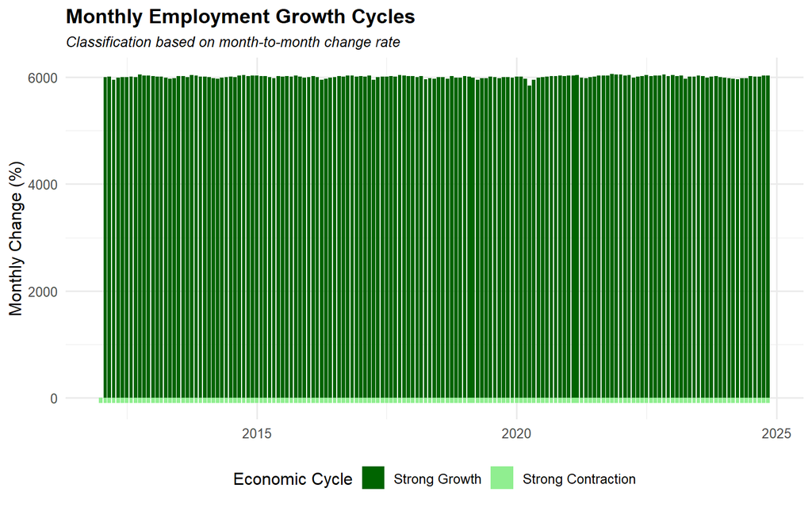

```r
# Create cycle classification variable
SIPA |>
  filter(Variable == "Empleo asalariado en el sector privado") |>
  arrange(Período) |>
  mutate(
    change_rate = (Valor / lag(Valor) - 1) * 100,
    cycle_status = case_when(
      change_rate > 0.5 ~ "Strong Growth",
      change_rate > 0 ~ "Moderate Growth",
      change_rate > -0.5 ~ "Moderate Contraction",
      TRUE ~ "Strong Contraction"
    ),
    cycle_status = factor(cycle_status, levels = c(
      "Strong Growth", "Moderate Growth",
      "Moderate Contraction", "Strong Contraction"
    ))
  ) |>
  filter(!is.na(cycle_status)) |>
  ggplot(aes(x = Período, y = change_rate, fill = cycle_status)) +
  geom_col() +
  scale_fill_manual(
    values = c("darkgreen", "lightgreen", "orange", "red")
  ) +
  labs(
    title = "Monthly Employment Growth Cycles",
    subtitle = "Classification based on month-to-month change rate",
    x = NULL,
    y = "Monthly Change (%)",
    fill = "Economic Cycle"
  ) +
  theme(legend.position = "bottom")
```

### Recursos adicionales

Para quienes quieran profundizar en estos conceptos:

#### R y Tidyverse

- Wickham, H., & Grolemund, G. (2023). *R for Data Science (2nd ed)*. O’Reilly Media. https://r4ds.hadley.nz/
- Healy, K. (2019). *Data Visualization: A Practical Introduction*. Princeton University Press. https://socviz.co/
- Hyndman, R.J., & Athanasopoulos, G. (2021). *Forecasting: Principles and Practice (3rd ed)*. OTexts. https://otexts.com/fpp3/

## Bibliografía

Wickham, H., & Grolemund, G. (2023). *R for Data Science (2nd ed)*. O'Reilly Media.

Tidyverse. (2023, April). *Base vs. magrittr pipe*. Retrieved from https://www.tidyverse.org/blog/2023/04/base-vs-magrittr-pipe/

DataViz Inspiration. (n.d.). Retrieved from https://www.dataviz-inspiration.com/

[Diplomatura Problemas Actuales de la Economía, el Empleo y el Comercio](https://ceped-fce-uba.github.io/diplomatura_economia/)

*diplo.problemas.economia@gmail.com*